# gradient-descent

## Introducción a Descenso por Gradiente y Regresión Lineal

```python
import numpy as np

import plotly
import plotly.graph_objs as py

plotly.offline.init_notebook_mode()

from sklearn.linear_model import LinearRegression

import matplotlib.pyplot as plt
import matplotlib.patches as mpatches
%matplotlib inline
```

### Importación de datos

```python
points = np.genfromtxt("data.csv", delimiter=",")
```

### Vamos a echar un vistazo a los primeros diezdatos

```python
for i in range(0,10):
    print str(i), points[i]
```

```
0 [ 32.50234527  31.70700585]
1 [ 53.42680403  68.77759598]
2 [ 61.53035803  62.5623823 ]
3 [ 47.47563963  71.54663223]
4 [ 59.81320787  87.23092513]
5 [ 55.14218841  78.21151827]
6 [ 52.21179669  79.64197305]
7 [ 39.29956669  59.17148932]
8 [ 48.10504169  75.3312423 ]
9 [ 52.55001444  71.30087989]
```

```python
len(points)
```

```
100
```

### Creación de listas de puntos

```python
x_points=[]
y_points=[]
for i in range(0, len(points)):
    x_points.append(points[i, 0])
    y_points.append(points[i, 1])
```

### Gráfico de dispersión con plotly

```python
trace = py.Scatter(x= x_points, y= y_points, mode = 'markers')
data = [trace]
plotly.offline.iplot(data)
```

[interactive chart not shown]

### Gráfica de Dispersión

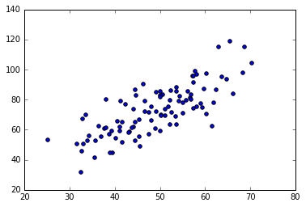

```python
plt.scatter(x_points,y_points)
```

### Correlación de Pearson

The Pearson correlation coefficient measures the linear relationship between two datasets. Strictly speaking, Pearson’s correlation requires that each dataset be normally distributed. Like other correlation coefficients, this one varies between -1 and +1 with 0 implying no correlation. Correlations of -1 or +1 imply an exact linear relationship. Positive correlations imply that as x increases, so does y.

```python
from scipy.stats.stats import pearsonr
pearsonr(x_points, y_points)
#(Pearson’s correlation coefficient, 2-tailed p-value)
```

```
(0.77372849988782377, 3.8556555369901578e-21)
```

### Función lineal

El model de regresión lineal consiste en ajustar un conjunto de puntos a una línea recta que sigue el modelo siguiente:

```python
# y = mx + b
m = 0
b = 0
y = lambda x : m*x + b
```

### Objetivo

Supongamos que quisieramos encontrar una línea que aproxime los puntos de nuestro gráfico. Para esto es necesario entender que la aproximación lineal está representada por y = mx +b, en donde m es la pendiente y b es la intercepción con el eje de la "y".

Para encontrar la mejor línea que se ajuste a nuestros datos, debemos de encontrar los mejores parámetros tanto de m como de b

### Aproximación desde el aprendizaje de máquina

Una aproximación es definir una función de error que mida que tan "bien" es una línea que atraviese los puntos. La idea es que esta función tenga como input un par (m,b) y regrese una medida de error. La propuesta es buscar una línea que minimce la distancia entre todos los puntos y ella. De esta manera, se tendría que iterar el calculo de esta distancia sobre los valores "y" y la línea propuesta (mx + b).

Entre mejor aproximación líneal menor error

### Gráfica lineal

```python
def plot_line(y, data_points):
    x_values = [i for i in range(int(min(data_points))-1, int(max(data_points))+2)]
    y_values = [y(x) for x in x_values]
    plt.plot(x_values, y_values, 'r')
```

Bajo los parametros establecidos con pendiente e intercepción igual a cero tendríamos una línea recta horizontal como lo muestra el siguiente gráfico:

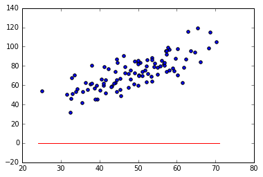

```python
plt.scatter(x_points,y_points)
plot_line(y, x_points)
```

## Algoritmo de descenso de gradiente

Es decir el gradiente se moverá en la dirección de x en una medida de $\partial (\frac {f(x, y)} {\partial x})$ y en la dirección de y en una medida de $\partial (\frac {f(x, y)} {\partial y})$

La magnitud, o el tamaño de gradiente se dará bajo el parámetro $\alpha$

De esta manera el operador de gradiente asegura que siempre se moverá en la dirección mejor, que se representa de la siguiente forma:

$\omega := \omega - \alpha \nabla_w f(\omega)$

```python
iterations = 500
alpha_learn = .001
length = len(x_points)
```

### Gradiente de m

Buscamos optimizar (minimizar) el gradiente de la siguiente función lineal del parametro m (pendiente):

$m = m - \alpha \frac{1}{k} \sum_{i=1}^{k} (f(x^{i}) - y^{i})$

```python
# y = mx + b
m = 0
b = 0
y = lambda x : m*x + b
```

```python
def suma_m(x_points, y_points, y):
    sumatoria = 0

    for i in range(0, length):
        sumatoria += y(x_points[i])-y_points[i]

    return sumatoria
```

```python
for i in range(iterations):
    m = m - (alpha_learn/length)*(suma_m(x_points, y_points, y))
```

```python
m
```

```
1.485651849744148
```

### Gradiente de b

Al mismo tiempo, buscamos optimizar (minimizar) el gradiente de la siguiente función lineal del parametro b (el interceptor con y):

```python
def suma_b(x_points, y_points, y):
    sumatoria = 0

    for i in range(0, length):
        sumatoria += (y(x_points[i])-y_points[i])*x_points[i]

    return sumatoria
```

```python
for i in range(iterations):
    b = b - (alpha_learn/length)*(suma_m(x_points, y_points, y))
```

```python
b
```

```
3.602382358280921e-10
```

### Aproximación de función lineal por descenso por gradiente

```
La función lineal final aproximada por descenso por gradiente es: y= 1.45734220715 *x + 1.38599314975
```

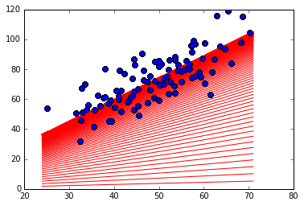

```python
# y = mx + b
m = 0
b = 0
y = lambda x : m*x + b

#Parametros necesarios para el proceso de optimización (aprendizaje)
alpha_learn = .001
iterations = 1000
length = len(x_points)
totalError = 0


for x in range(iterations):
    m = m - (alpha_learn/length)*(suma_m(x_points, y_points, y))
    b = b - (alpha_learn/length)*(suma_m(x_points, y_points, y))
    plot_line(y, x_points)
    plt.plot(x_points, y_points, 'bo')


print "La función lineal final aproximada por descenso por gradiente es: " "y=", m,"*x +", b
```

```
La función lineal final aproximada por descenso por gradiente es: y= 1.45734220715 *x + 1.38599314975
El error cuadrático medio es 238.628339155
```

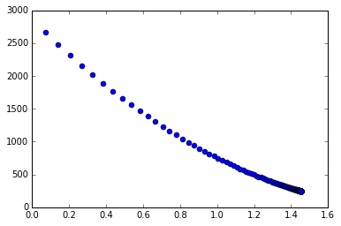

```python
# y = mx + b
m = 0
b = 0
y = lambda x : m*x + b

alpha_learn = .001
iterations = 1000
length = len(x_points)
totalError = 0


for x in range(iterations):
    m = m - (alpha_learn/length)*(suma_m(x_points, y_points, y))
    b = b - (alpha_learn/length)*(suma_m(x_points, y_points, y))
    #plot_line(y, x_points)
    #plt.plot(x_points, y_points, 'bo')

    for i in range(0, len(points)):
        e = 0
        e= np.mean((y_points[i] - y(x_points[i])) ** 2)

    plt.plot(m, e,'bo')


print "La función lineal final aproximada por descenso por gradiente es: " "y=", m,"*x +", b

#Calculamos el error cuadrático medio
e= np.mean((y_points[i] - y(x_points[i])) ** 2)
print "El error cuadrático medio es", e
```

## Aproximación lineal por mínimos cuadrádos

### Ajustamos los datos para introducir el modelo líneal

```python
X = np.reshape(x_points, (-1,1))
Y = np.reshape(y_points, (-1,1))

linReg=LinearRegression()
linReg.fit(X,Y)
```

```
LinearRegression(copy_X=True, fit_intercept=True, n_jobs=1, normalize=False)
```

### Obtención de los parametros estimados

```python
b=linReg.intercept_
m=linReg.coef_
type(b)
print str("b="), b[0]
print str("m="), m[0][0]
```

```
b= 7.99102098227
m= 1.32243102276
```

```python
# y = mx + b
b=float(linReg.intercept_)
m=float(linReg.coef_)
y = lambda x : m*x + b
```

### Gráfico de ambos modelos

```python
def plot_line_rl(y, data_points):
    x_values = [i for i in range(int(min(data_points))-1, int(max(data_points))+2)]
    y_values = [y(x) for x in x_values]
    plt.plot(x_values, y_values, 'r')
    #red_patch = mpatches.Patch(color='red', label='Minimos cuadrados ordinarios')
    #plt.legend(handles=[red_patch], loc=4)
```

```python
def plot_line_dg(y, data_points):
    x_values = [i for i in range(int(min(data_points))-1, int(max(data_points))+2)]
    y_values = [y(x) for x in x_values]
    plt.ylabel('y values')
    plt.xlabel('x values')
    plt.plot(x_values, y_values, 'b')
    #bandera azul
    blue_patch = mpatches.Patch(color='blue', label='Descenso por gradiente')

    #bandera roja
    red_patch = mpatches.Patch(color='red', label='Minimos cuadrados ordinarios')

    plt.legend(handles=[red_patch,blue_patch], loc=1)
```

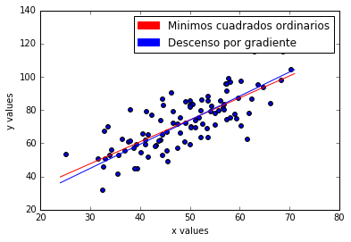

```python
plt.scatter(x_points,y_points)
plot_line_rl(y, x_points)
b=1.38
m=1.45

plt.scatter(x_points,y_points)
plot_line_dg(y, x_points)
```